# Conceitos de estatística descritiva

A estatística descritiva pode ser entendida como uma ferramenta capaz de descrever ou resumir dados, mostrando aspectos importantes do conjunto de dados, como o tipo de distribuição associada e os valores mais representativos do conjunto, e permitindo criar visualizações referentes a tais aspectos.

### População, amostra e variáveis

Os conceitos de população , amostra e variáveis são brevemente comentados nesta seção.

## População

População, ou universo, é o nome que se dá a um conjunto de unidades (elementos ou exemplares/dados se aproximarmos a definição ao contexto de mineração de dados) que compartilham características comuns e sobre o qual é pretendido o desenvolvimento de um estudo.

O conjunto de vendas realizadas durante o tempo de funcionamento de um restaurante é um exemplo de população (de vendas).

A população pode ser finita ou infinita.

Sendo finita, se pequena, um estudo pode envolver sua totalidade. Caso seja muito grande ou infinita, faz-se necessário estabelecer uma amostra, para que um estudo sobre ela se viabilize.

## Amostra

Uma amostra, então, é um subconjunto da população (também chamado de fração ou parte) que deve ser estabelecido com cuidado, seguindo técnicas apropriadas, pois o objetivo de obter uma amostra é reduzir o tamanho da população sem que características essenciais associadas a ela sejam perdidas.

Boas técnicas de amostragem geram amostras representativas e imparciais da população, ou seja, mantêm a proporcionalidade dos fenômenos que ocorrem na população e conferem chances iguais aos elementos da população de fazerem parte da amostra.

Há diferentes formas de estabelecer uma amostra, que resultam em diferentes tipos de amostragem: aleatória, estratificada, por conglomerados, acidental, intencional, por quotas etc...

[figure not shown]

## Variável

Na estatística descritiva, uma variável diz respeito a uma característica associada a elementos de uma população.

Por exemplo, num restaurante, uma variável pode ser a temperatura em que um vinho deve ser servido (com valores como 5°C ou 12°C) ou o tipo de um prato presente no cardápio (com os seguintes valores, por exemplo: aperitivo, pasta, carne branca ou sobremesa quente).

Fazendo uma analogia à representação de um dado usada neste livro, uma variável é equivalente a um atributo descritivo. As variáveis, no contexto da estatística descritiva, podem ser **quantitativas** ou **qualitativas**.

[figure not shown]

## Variável Quantitativa

As **variáveis quantitativas** (também nomeadas no contexto de mineração de dados como variáveis numéricas) são aquelas que podem ser medidas em uma escala de valores numéricos, e se dividem em **discretas** (assumem valores dentro de um conjunto finito ou infinito contável) ou **contínuas** (assumem valores em uma escala contínua).

## Variável Qualitativa

As **variáveis qualitativas** (também nomeadas no contexto de mineração de dados como variáveis categóricas) são aquelas que representam uma classificação do elemento ao qual o valor da variável está associado, e se dividem em **nominais** (quando não há ordenação entre valores) ou **ordinais** (quando há uma ordenação entre os valores). Alguns exemplos de variáveis, considerando o contexto de um restaurante, e alguns valores que elas podem assumir estão organizados a seguir

## Variáveis quantitativas

### Discretas

> **Quantidade de bebidas vendidas: 15, 6, 3, 0**  
> **Idade do cliente: 5, 10, 25, 32, 57**

### Contínuas

> **Preço de um item do cardápio: 5,50, 35,00, 99,50**  
> **Peso de um corte de carne: 100g, 226g, 500g**

## Variáveis qualitativas

### Nominais

> **Código da forma de pagamento: 11, 21, 31**  
> **Forma de pagamento: dinheiro, débito, crédito**

### Ordinais

> **Faixa etária dos clientes: 0 a 10 anos, 11 a 17 anos, 18 a 30 anos, 31 a 50 anos, mais de 50 anos**  
> **Mês de observação: janeiro, abril, novembro**

## Medidas de posição e separatrizes

Medidas de posição , ou medidas de tendência central , permitem encontrar os valores que orientam a análise dos dados no que diz respeito à sua localização, ou como a distribuição associada aos valores se comporta no universo amostrado.

As medidas de posição mais comuns no contexto de análise exploratória de dados são média aritmética, mediana e moda. Relacionadas com a mediana estão as medidas separatrizes percentis e quartis.

Para um conjunto de valores $v = {v_1,v_2,...,v_n}$, em que $n$ é a quantidade de valores do conjunto, a média aritmética simples (média(v) ou ) é a soma dos valores do conjunto v, dividida pela quantidade de valores presentes nesse conjunto.

Formalmente, $média (v)$ é definida como:

$$ media (v) = \frac{1}{n}\sum_{i=1}^{n}v_{i} $$

A **mediana** ($mediana(v)$) é o valor que divide a distribuição dos valores exatamente ao meio (podendo ser vista também como uma medida separatriz).

Importante lembrar que tal valor não precisa estar presente no conjunto $v$.

A **moda** , por sua vez, é o valor mais frequente em um conjunto de valores.

Ela é a única medida de posição que pode assumir mais de um valor.

Essa situação ocorre quando dois ou mais valores aparecem no conjunto de valores v com a mesma frequência, a máxima no conjunto. Assim, um conjunto de valores pode ser:

- **amodal** (não possui moda),
- **unimodal** (possui uma moda),
- **bimodal** (possui duas modas) ou
- **multimodal** (possui diversas modas).

## Exemplos

Para exemplificar o uso dessas medidas e como a comparação entre elas pode ser útil, considere os dados da Tabela 1 a seguir, que representa a quantidade de vendas, durante um mês, dos nove itens presentes no cardápio promocional de um restaurante.

### Quantidade de vendas de nove itens do restaurante durante um mês

| Item | 712 | 68 | 2 | 65 | 103 | 809 | 111 | 601 | 44 |
| --- | --- | --- | --- | --- | --- | --- | --- | --- | --- |
| Quantidade | 29 | 30 | 32 | 65 | 65 | 65 | 25 | 25 | 90 |

Presumindo que se queira calcular as medidas de posição em relação à variável **Quantidade**, por causa da **mediana**, e apenas por causa dela, é preciso ordenar os dados da Tabela 2 considerando os valores dessa variável (Tabela 2).

## Quantidade de vendas ordenada

|  | 1 | 2 | 3 | 4 | 5 | 6 | 7 | 8 | 9 |
| --- | --- | --- | --- | --- | --- | --- | --- | --- | --- |
| Item | 601 | 111 | 712 | 68 | 2 | 65 | 103 | 809 | 44 |
| Quantidade | 25 | 25 | 29 | 30 | 32 | 65 | 65 | 65 | 90 |

| Item | 712 | 68 | 2 | 65 | 103 | 809 | 111 | 601 | 44 |
| --- | --- | --- | --- | --- | --- | --- | --- | --- | --- |
| Quantidade | 29 | 30 | 32 | 65 | 65 | 65 | 25 | 25 | 90 |

Iniciando a análise exploratória desses dados pelo cálculo da média, com o uso da Fórmula da Média, tem-se:

$média(Quantidade)=(25 + 25 + 29 + 30 + 32 + 65 + 65 + 65 + 90)/9 = 47,3.$

Para o cálculo da mediana, desde que haja uma quantidade ímpar de valores, tem-se:

$i = (n + 1)/2 = (9 + 1)/2 = 5$

e, portanto, $mediana(Quantidade) = 32$,

ou seja, a mediana é o valor da variável Quantidade na quinta posição da ordenação.

Enfim, a moda é o valor com maior quantidade de repetições.

No caso da variável Quantidade, o valor 65 aparece três vezes, enquanto todos os demais valores aparecem uma ou duas vezes; portanto, 65 é a moda do conjunto.

As medidas de posição calculadas para a variável Quantidade estão resumidas na Tabela 3

### Medidas de posição para a variável Quantidade

| Média | Mediana | Moda |
| --- | --- | --- |
| 47,33 | 32 | 65 |

Em termos práticos, essas medidas permitem algumas intepretações sobre o cardápio:

- durante o mês de observação, a quantidade média de vendas de um item foi de 47,33 unidades;
- a mediana revela que, embora as vendas para o item 002 sejam em quantidade maior que as vendas para metade dos itens observados (é o quinto mais vendido dentro de nove itens), a venda desse item está abaixo da média de vendas do conjunto.

### Entendendo um pouco masi sobre os dados de vendas

A comparação da média, mediana e moda pode revelar informações interessantes sobre a distribuição dos valores do conjunto em questão.

Quando essas medidas assumem o mesmo valor (ou valores com variações muito pequenas entre si) significa que o conjunto de valores de uma variável tem **simetria**, ou seja, é possível usar uma dessas medidas de posição para separar o conjunto de valores em duas partes com a mesma distribuição de frequência.

Por outro lado, se os valores são diferentes, diz-se que a distribuição dos valores da variável é **assimétrica** .

No exemplo da variável Quantidade, a média, a mediana e a moda assumem valores diferentes, o que indica que a distribuição da quantidade de vendas é assimétrica.

Nesse caso, menos da metade dos itens vende mais que a média (quatro itens vendem mais e cinco itens vendem menos).

### Percentis e Quartis

Os **percentis** e **quartis** são medidas separatrizes que dividem o conjunto de valores, ordenado de forma crescente, em partes tão iguais quanto possível.

O **percentil de ordem p** determina os **p% menores valores contidos em v’**, e a posição i, que delimita o percentil de ordem p em v’, é dada por:

$$ i=\frac{p(n+1)}{100} $$

Isso significa que os p% menores valores em v’ estão abaixo do valor da posição $i$.

Então, considerando a variável Quantidade (Tabela 2), o percentil de ordem p = 50 indica os 50% menores valores no conjunto ordenado e estão abaixo do valor localizado na posição dadda por: $$ i=\frac{50(9+1)}{100}=5 $$ Assim, o valor 32 é o percentil de ordem 50 em v’.

|  | 1 | 2 | 3 | 4 | 5 | 6 | 7 | 8 | 9 |
| --- | --- | --- | --- | --- | --- | --- | --- | --- | --- |
| Quantidade | 25 | 25 | 29 | 30 | 32 | 65 | 65 | 65 | 90 |

### Casos particulares de percentis definem os quartis

O primeiro quartil , ou Q1, é o percentil de ordem p = 25, ou seja, o valor de v que separa os 25% valores menores que vi dos 75% valores maiores que vi, sendo vi o valor que ocupa a $i=\frac{25(n+1)}{100}$

O segundo quartil, ou Q2, é o percentil de ordem p = 50 e é equivalente à mediana do conjunto de valores.

O terceiro quartil, ou Q3, é equivalente ao percentil de ordem p = 75 e é o valor que separa os 75% valores menores que vi dos 25% valores maiores que $v_i$, sendo $v_i$ o valor que ocupa a $i=\frac{75(n+1)}{100}$ posição em v’.

Para o caso da variável Quantidade (Tabela 2), Q1, Q2 e Q3 são, respectivamente,

- $v_3 = 29$,
- $v_5 = 32$,
- $v_8 = 65$.

Em termos práticos, poderíamos dizer que o item 044 está acima do percentil de ordem 75 ou acima de Q3, indicando que pelo menos 75% dos itens observados vendem menos que ele, evidenciando sua boa aceitação por parte dos clientes.

|  | 1 | 2 | 3 | 4 | 5 | 6 | 7 | 8 | 9 |
| --- | --- | --- | --- | --- | --- | --- | --- | --- | --- |
| Item | 601 | 111 | 712 | 68 | 2 | 65 | 103 | 809 | 44 |
| Quantidade | 25 | 25 | 29 | 30 | 32 | 65 | 65 | 65 | 90 |

## Medidas de dispersão

As medidas de posição são úteis para apresentar uma sumarização dos dados. No entanto, não são capazes de descrever a variação ou dispersão do conjunto de valores.

Para esse fim, aplicam-se as medidas de dispersão , capazes de descrever o quanto os valores de um conjunto estão próximos ou distantes de uma medida central, como a média.

As medidas mais comuns de dispersão ou variância dos dados são a **amplitude**, **variância**, **desvio-padrão**.

## Amplitude

Para um conjunto de valores v, a medida da amplitude é a diferença entre o maior e o menor valor do conjunto, portanto: $$ amplitude (v) = max (v) – min (v). $$

Embora a medida da amplitude seja simples, sua interpretação precisa ser feita com cuidado, pois ela pode ser influenciada por valores extremos, conhecidos como outliers que veremos mais a frente.

## Variância

A **variância** $\sigma^2(v)$ é uma medida de dispersão definida como a média dos quadrados das diferenças entre cada valor do conjunto v e a média desse conjunto. Formalmente, tem-se: $$ \sigma^2 (v) = \frac{1}{n}\sum_{i=1}^{n}(v_i - media(v))^2 $$

### Desvio-padrão

O **desvio-padrão** $\sigma(v)$ é a raiz quadrada da variância.

O uso do desviopadrão só faz sentido quando a média for usada como medida de posição (ou de centro).

Ele é semelhante à medida de amplitude, com a diferença de que o cálculo do desvio-padrão usa todos os valores de um conjunto.

O resultado dessa medida geralmente é usado para verificar a consistência de um fenômeno (um fenômeno é consistente quando o cálculo do desvio-padrão resulta em valores baixos).

Outra utilidade para o desvio-padrão é conhecida como regra empírica , ou regra 68-95-99 ou ainda regra dos 3-sigmas .

- Essa regra se aplica a conjunto de valores com distribuição normal e afirma que aproximadamente 68% dos valores desse conjunto estão a menos de um desvio-padrão da sua média;
- 95% dos valores desse conjunto estão a menos de dois desvios-padrão da sua média;
- 99,7% dos valores desse conjunto estão a menos de três desvios-padrão da sua média.

[figure not shown]

### Exemplo Utilizando o R

```r
Quantidade <- c(29,30,32,65,65,65,25,25,90)
```

```r
Quantidade
```

1. 29

2. 30

3. 32

4. 65

5. 65

6. 65

7. 25

8. 25

9. 90

```r
mean(Quantidade)
```

47.3333333333333

```r
median(Quantidade)
```

32

```r
Mode <- function(x) {
     ux <- unique(x)
     ux[which.max(tabulate(match(x, ux)))]
}
Mode(Quantidade)
```

65

```r
sd(Quantidade)
```

24.0468293128221

```r
var(Quantidade)
```

578.25

```r
range(Quantidade)
```

1. 25

2. 90

```r
max(Quantidade)
```

90

```r
min(Quantidade)
```

25

```r
amplitude = max(Quantidade)-min(Quantidade)
amplitude
```

65

```r
Q1 <- quantile(Quantidade, probs = 0.25)
Q2 <- quantile(Quantidade, probs = 0.50)
Q3 <- quantile(Quantidade, probs = 0.75)
Q4 <- quantile(Quantidade, probs = 1.00)

quartis <- c(Q1,Q2,Q3,Q4)

quartis
```

**25%**

29

**50%**

32

**75%**

65

**100%**

90

```r
Q1
```

**25%:** 29

## Exemplo Prático de Nálise do dataset Iris

Como não poderia deixar de ser, a primeira parte de um projeto de data science segue a mesma lógica de um projeto de análise estatística de dados. Precisamos fazer a análise exploratória a fim de entender o conjunto de dados com o qual estamos trabalhando.

O conjunto de dados que vou baixar se chama Iris Flower Dataset. Por ser multivariado e com um número razoável de observações, este conjunto é bastante famoso na literatura estatística. Até mesmo Fisher já trabalhou conceitos de análise multivariada com estes dados.

Seu nome é Iris porque foram coletadas observações de 150 sujeitos de 3 espécies de flores do gênero Iris: Iris setosa, Iris versicolor e Iris virginica. Mais informações sobre estas flores podem ser encontradas na [Wikipedia](https://en.wikipedia.org/wiki/Iris_flower_data_set).

[figure not shown]

```r
# definir o endereco do conjunto de dados e baixa-lo
url <- "https://archive.ics.uci.edu/ml/machine-learning-databases/iris/iris.data"
iris <- read.csv(url, header = FALSE)
names(iris) <- c("c_sepala", "l_sepala", "c_petala", "l_petala",
    "especie")
# remover a string 'Iris-' do inicio de cada tipo de especie
iris$especie <- as.factor(gsub("Iris-", "", iris$especie))
```

Com isso, percebemos que temos um conjunto de dados formado por cinco variáveis. Quatro destas variáveis são quantitativas e uma é categórica. As variáveis são

- c_sepala: comprimento da sépala das flores
- l_sepala: largura da sépala das flores
- c_petala: comprimento da pétala das flores
- l_petala: largura da pétala das flores
- especie: espécie da flor

```r
head(iris) # exibe as 6 primeiras linhas do conjunto de dados para me dar uma ideia do que estou enfrentando
```

A data.frame: 6 × 5

|  | c_sepala <dbl> | l_sepala <dbl> | c_petala <dbl> | l_petala <dbl> | especie <fct> |
| --- | --- | --- | --- | --- | --- |
| 1 | 5.1 | 3.5 | 1.4 | 0.2 | setosa |
| 2 | 4.9 | 3.0 | 1.4 | 0.2 | setosa |
| 3 | 4.7 | 3.2 | 1.3 | 0.2 | setosa |
| 4 | 4.6 | 3.1 | 1.5 | 0.2 | setosa |
| 5 | 5.0 | 3.6 | 1.4 | 0.2 | setosa |
| 6 | 5.4 | 3.9 | 1.7 | 0.4 | setosa |

```r
names(iris) # Exibe as colunas do dataframe iris
```

1. 'c_sepala'

2. 'l_sepala'

3. 'c_petala'

4. 'l_petala'

5. 'especie'

```r
# O resumo summary apresenta alguns detalhes muito importantes, incluindo percepções estatísticas
summary(iris)
```

```
    c_sepala        l_sepala        c_petala        l_petala
 Min.   :4.300   Min.   :2.000   Min.   :1.000   Min.   :0.100
 1st Qu.:5.100   1st Qu.:2.800   1st Qu.:1.600   1st Qu.:0.300
 Median :5.800   Median :3.000   Median :4.350   Median :1.300
 Mean   :5.843   Mean   :3.054   Mean   :3.759   Mean   :1.199
 3rd Qu.:6.400   3rd Qu.:3.300   3rd Qu.:5.100   3rd Qu.:1.800
 Max.   :7.900   Max.   :4.400   Max.   :6.900   Max.   :2.500
       especie
 setosa    :50
 versicolor:50
 virginica :50
```

```r
sd(iris$c_sepala)
```

0.828066127977863

```r
var(iris$c_sepala)
```

0.685693512304251

```r
range(iris[,1:4])
```

1. 0.1

2. 7.9

```r
head(iris[,1:4])
```

A data.frame: 6 × 4

|  | c_sepala <dbl> | l_sepala <dbl> | c_petala <dbl> | l_petala <dbl> |
| --- | --- | --- | --- | --- |
| 1 | 5.1 | 3.5 | 1.4 | 0.2 |
| 2 | 4.9 | 3.0 | 1.4 | 0.2 |
| 3 | 4.7 | 3.2 | 1.3 | 0.2 |
| 4 | 4.6 | 3.1 | 1.5 | 0.2 |
| 5 | 5.0 | 3.6 | 1.4 | 0.2 |
| 6 | 5.4 | 3.9 | 1.7 | 0.4 |

### ESTATÍSTICAS DESCRITIVAS

### Qual é a distribuição quantitativa das variáveis?

### Esta pergunta é respondida usando um gráfico do histograma e boxplot das variáveis.

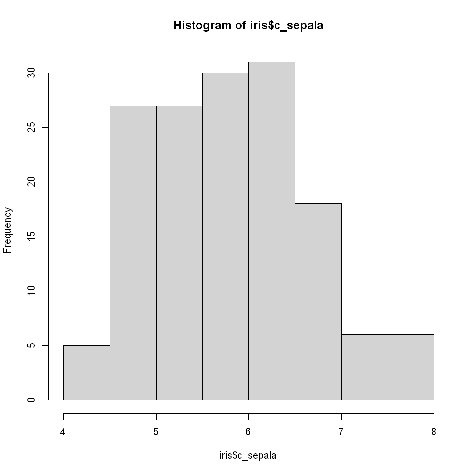

```r
library(repr)
options(repr.plot.width=8, repr.plot.height=8)
hist(iris$c_sepala)
```

### Alguns insights do histograma:

1. A partir do histograma, vemos que o comprimento da sépala varia de 4 a 8
2. enquanto a frequência varia de 5 a 30.
3. Também pode ser visto que a frequência mais alta tem comprimento de sépala que varia de 6 a 6,5 enquanto a segunda frequência mais alta tem uma faixa de comprimento sépala entre 5,5 e aproximadamente 6
4. O comprimento da sépala com a menor frequência varia de 4 a 4,5

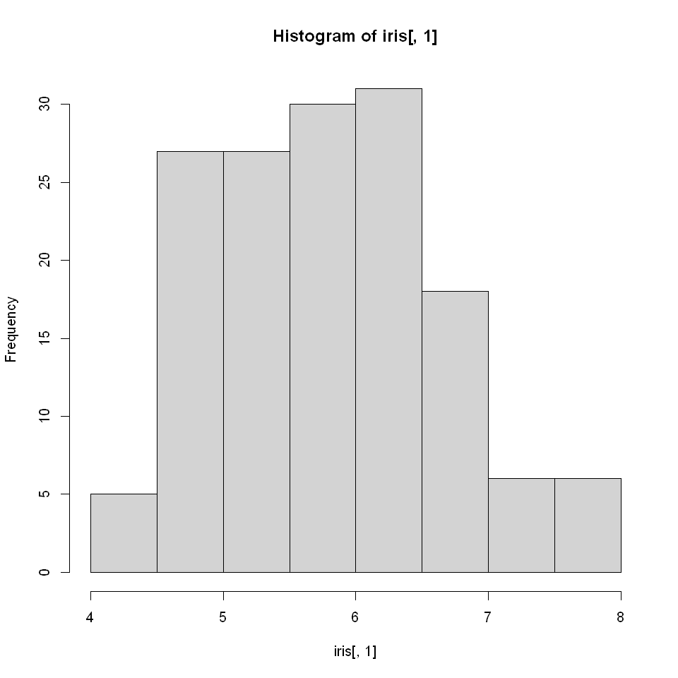

```r
hist(iris[,1])
```

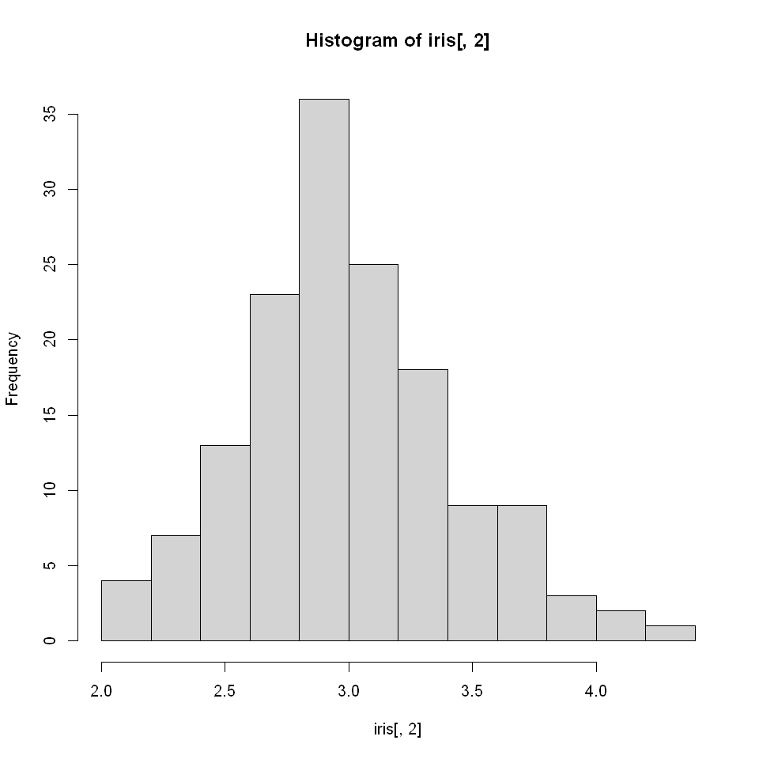

```r
hist(iris[,2])
```

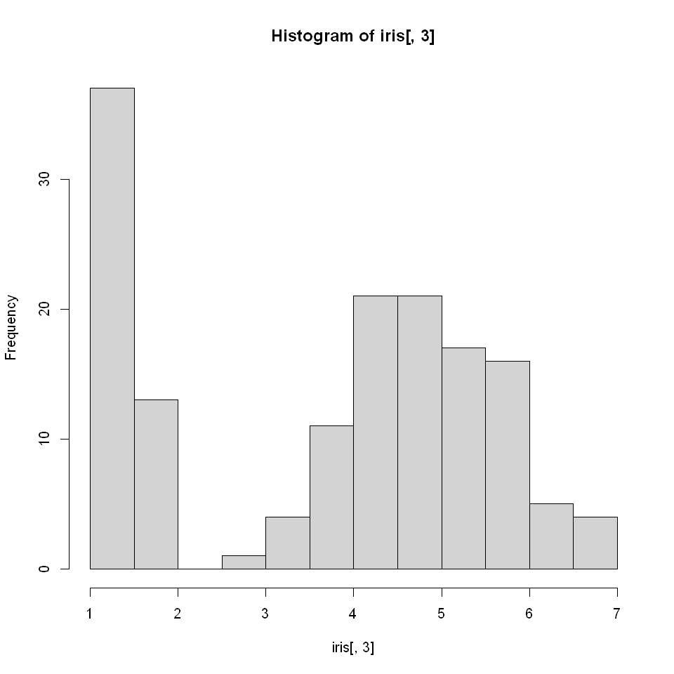

```r
hist(iris[,3])
```

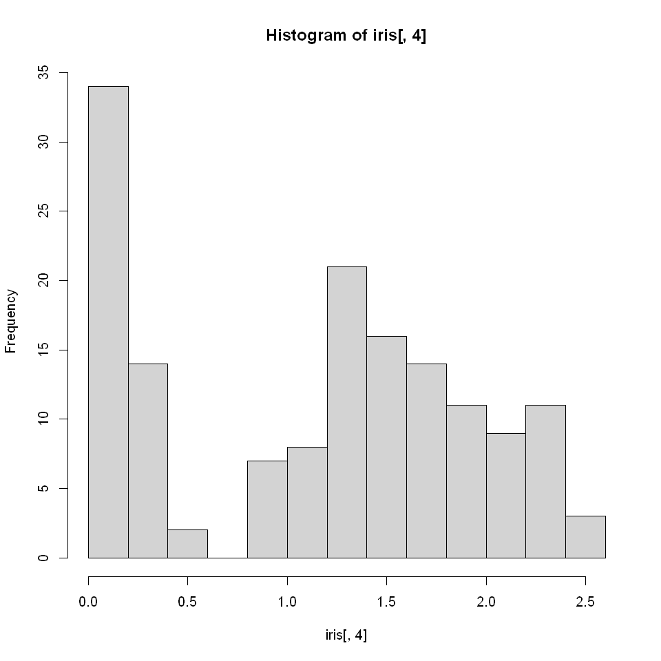

```r
hist(iris[,4])
```

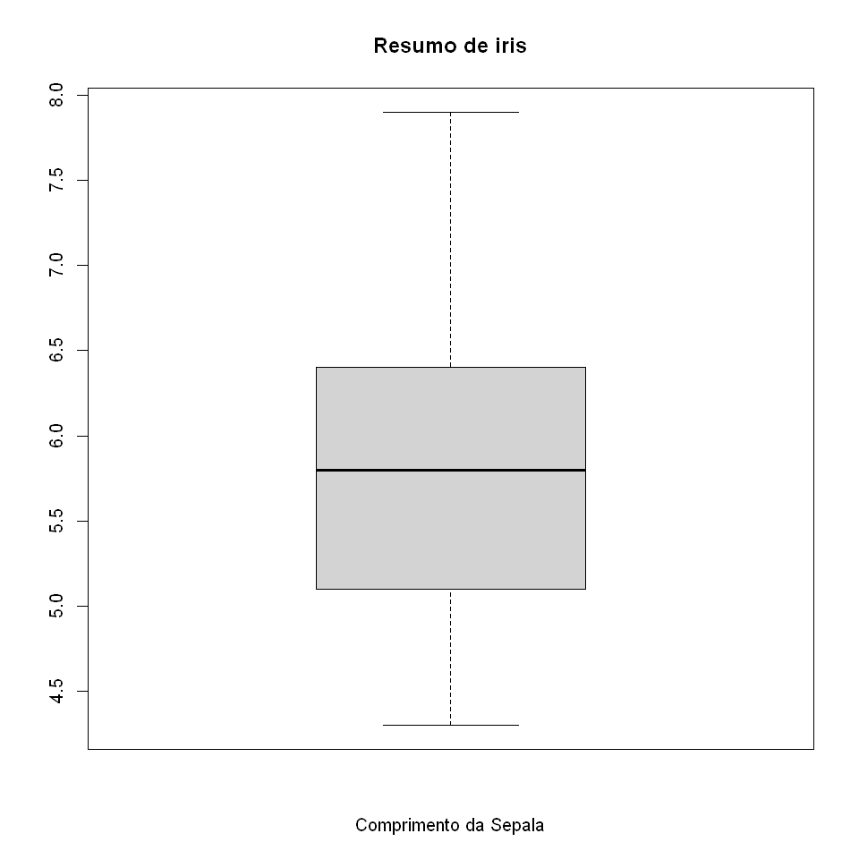

```r
# O boxplot é usado para exibir o mesmo abaixo:
boxplot(iris$c_sepala,main="Resumo de iris",xlab="Comprimento da Sepala")
```

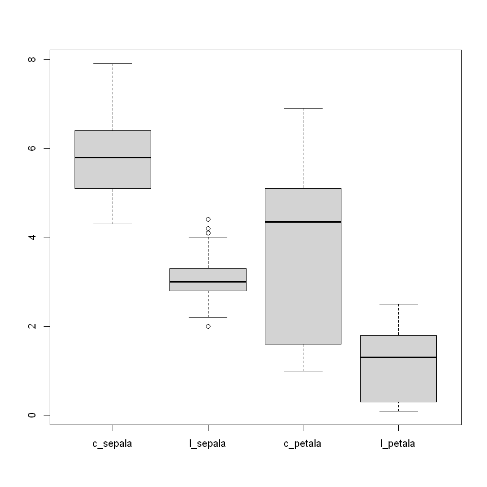

```r
boxplot(iris[,1:4])
```

```r
iris$c_sepala
```

1. 5.1

2. 4.9

3. 4.7

4. 4.6

5. 5

6. 5.4

7. 4.6

8. 5

9. 4.4

10. 4.9

11. 5.4

12. 4.8

13. 4.8

14. 4.3

15. 5.8

16. 5.7

17. 5.4

18. 5.1

19. 5.7

20. 5.1

21. 5.4

22. 5.1

23. 4.6

24. 5.1

25. 4.8

26. 5

27. 5

28. 5.2

29. 5.2

30. 4.7

31. 4.8

32. 5.4

33. 5.2

34. 5.5

35. 4.9

36. 5

37. 5.5

38. 4.9

39. 4.4

40. 5.1

41. 5

42. 4.5

43. 4.4

44. 5

45. 5.1

46. 4.8

47. 5.1

48. 4.6

49. 5.3

50. 5

51. 7

52. 6.4

53. 6.9

54. 5.5

55. 6.5

56. 5.7

57. 6.3

58. 4.9

59. 6.6

60. 5.2

61. 5

62. 5.9

63. 6

64. 6.1

65. 5.6

66. 6.7

67. 5.6

68. 5.8

69. 6.2

70. 5.6

71. 5.9

72. 6.1

73. 6.3

74. 6.1

75. 6.4

76. 6.6

77. 6.8

78. 6.7

79. 6

80. 5.7

81. 5.5

82. 5.5

83. 5.8

84. 6

85. 5.4

86. 6

87. 6.7

88. 6.3

89. 5.6

90. 5.5

91. 5.5

92. 6.1

93. 5.8

94. 5

95. 5.6

96. 5.7

97. 5.7

98. 6.2

99. 5.1

100. 5.7

101. 6.3

102. 5.8

103. 7.1

104. 6.3

105. 6.5

106. 7.6

107. 4.9

108. 7.3

109. 6.7

110. 7.2

111. 6.5

112. 6.4

113. 6.8

114. 5.7

115. 5.8

116. 6.4

117. 6.5

118. 7.7

119. 7.7

120. 6

121. 6.9

122. 5.6

123. 7.7

124. 6.3

125. 6.7

126. 7.2

127. 6.2

128. 6.1

129. 6.4

130. 7.2

131. 7.4

132. 7.9

133. 6.4

134. 6.3

135. 6.1

136. 7.7

137. 6.3

138. 6.4

139. 6

140. 6.9

141. 6.7

142. 6.9

143. 5.8

144. 6.8

145. 6.7

146. 6.7

147. 6.3

148. 6.5

149. 6.2

150. 5.9

```r
summary(iris$c_sepala)
```

```
   Min. 1st Qu.  Median    Mean 3rd Qu.    Max.
  4.300   5.100   5.800   5.843   6.400   7.900
```

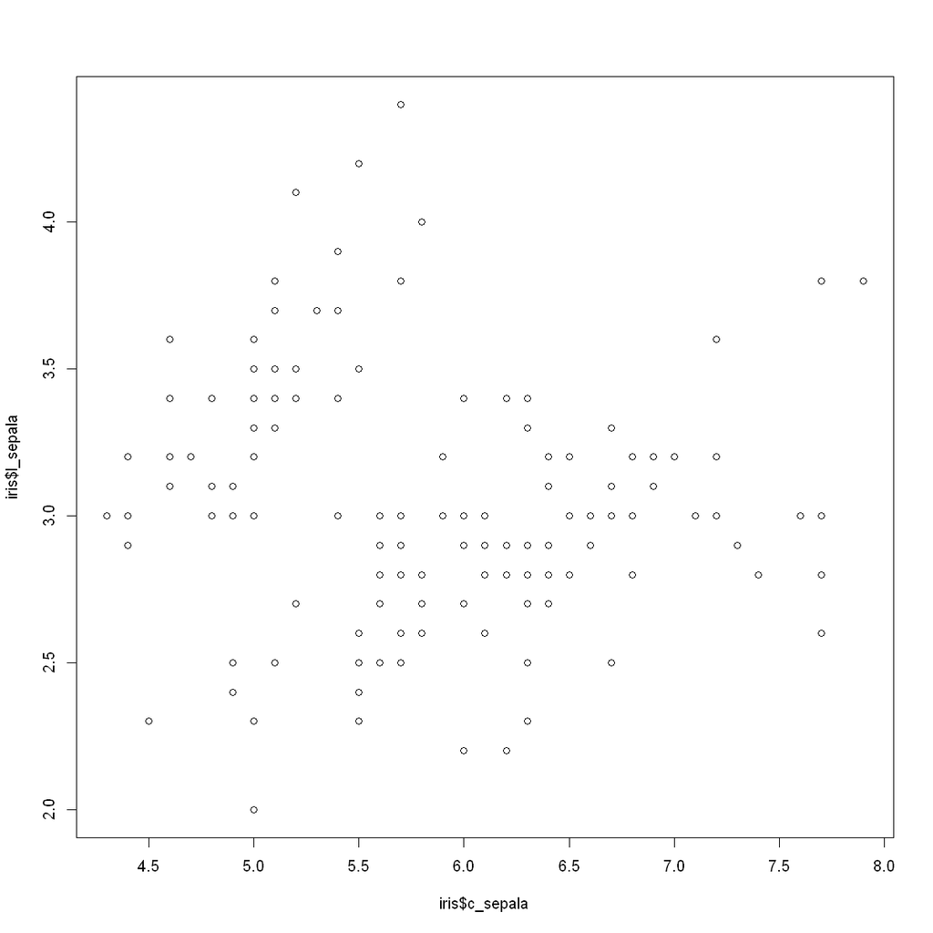

```r
# EXPLORANDO A RELAÇÃO ENTRE O SEPAL COMPRIMENTO E A LARGURA USANDO PLOTS DE DISPERSÃO
options(repr.plot.width=10, repr.plot.height=10)
plot(iris$c_sepala, iris$l_sepala)
```

### INSIGHTS DO SCATTER PLOT

1. O gráfico de dispersão sugere que pode não haver uma relação forte entre o comprimento e a largura da sépala.
2. A realização de modelos de regressão linear e análise de correlação pintará uma imagem melhor da relação.

A função de `plot` convencional faz o trabalho, mas para obter uma visualização melhor e mais aprimorada, Vamos usar o pacote `ggplot` para traçar o gráfico de dispersão

```r
names(iris)
```

1. 'c_sepala'

2. 'l_sepala'

3. 'c_petala'

4. 'l_petala'

5. 'especie'

```r
install.packages("ggplot2")
```

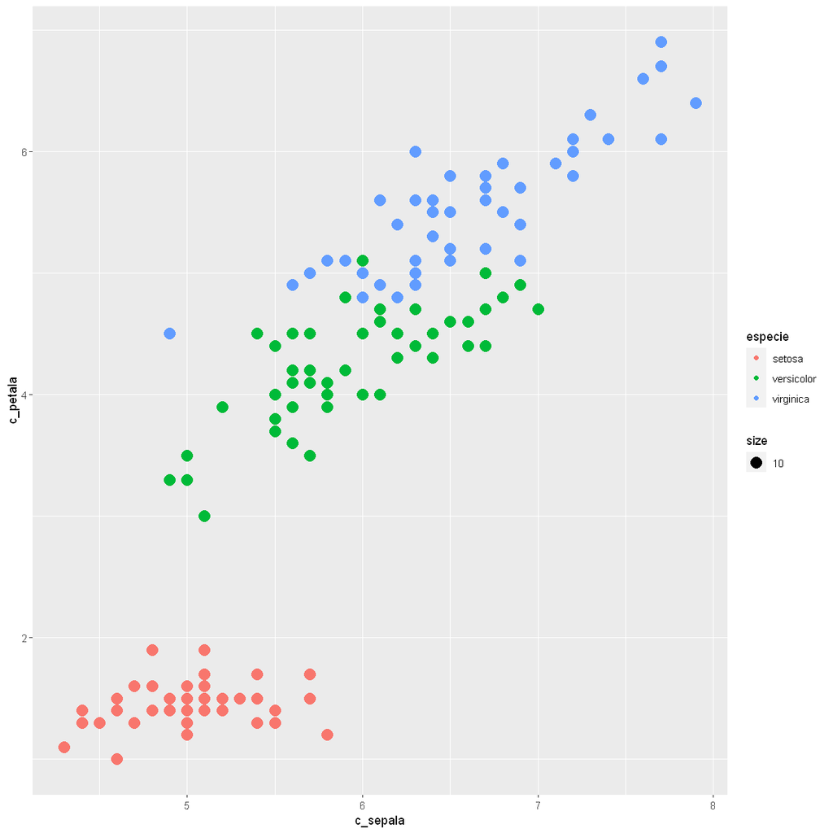

```r
options(repr.plot.width=10, repr.plot.height=10)
library(ggplot2)
qplot(c_sepala, c_petala, data = iris, color = especie, size=10)
```

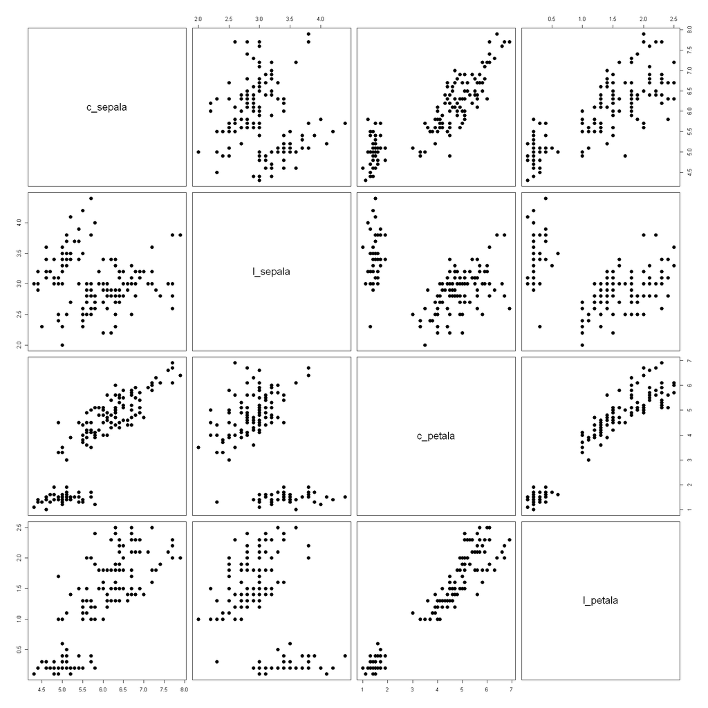

```r
options(repr.plot.width=15, repr.plot.height=15)
pairs(iris[,1:4], pch = 19, cex=1.5)
```

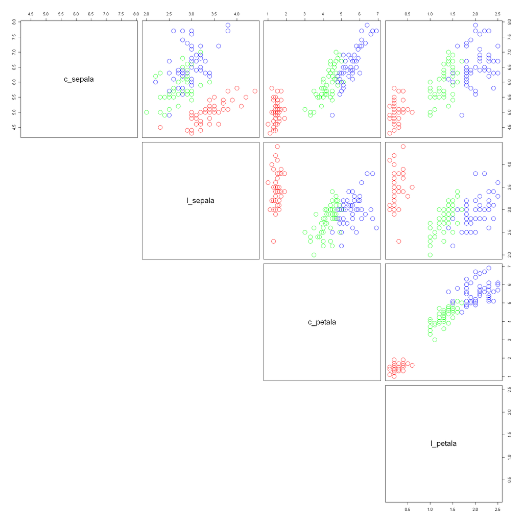

```r
my_cols <- c("red", "green", "blue")
options(repr.plot.width=15, repr.plot.height=15)
pairs(iris[,1:4], pch = 1,  cex = 2.5,
      col = my_cols[iris$especie],
      lower.panel=NULL)
```